# Graph Visualizations In Python

I was chatting with my sister the other day about graphs and graph anaysis in Python. She works at the [Innovation Institute for Food and Health](http://foodaghealth.solutions/) at UC Davis and is doing systems analysis of people and research and their impact on food and agriculture in California. I realized I hadn't done anything fun in this area in a while, so I downloaded a dataset that seemed comprable to test out using a library. Once I started actually looking at the dataset, I realized I just wanted to analyze it anyway!

# Nation Science Foundation: Research Experience for Undergraduates

[Synopsis](https://www.nsf.gov/funding/pgm_summ.jsp?pims_id=5517)

> The Research Experiences for Undergraduates (REU) program supports active research participation by undergraduate students in any of the areas of research funded by the National Science Foundation. REU projects involve students in meaningful ways in ongoing research programs or in research projects specifically designed for the REU program. This solicitation features two mechanisms for support of student research: (1) REU Sites are based on independent proposals to initiate and conduct projects that engage a number of students in research. REU Sites may be based in a single discipline or academic department or may offer interdisciplinary or multi-department research opportunities with a coherent intellectual theme. Proposals with an international dimension are welcome. (2) REU Supplements may be included as a component of proposals for new or renewal NSF grants or cooperative agreements or may be requested for ongoing NSF-funded research projects.

For each REU program, we get the name of the institute, its location, and some of the research topics they are engaged in.

The data analysis plan here will be to:

# Data Prep

```python
from time import time
from re import sub
from io import StringIO

import numpy as np
import pandas as pd
import seaborn as sns
import holoviews as hv
import networkx as nx

from matplotlib import pyplot as plt
from sklearn.cluster import KMeans
from sklearn.feature_extraction.text import TfidfVectorizer
from sklearn.decomposition import LatentDirichletAllocation

hv.extension('bokeh')

%opts Graph [width=800 height=800]
%matplotlib inline
```

```python
# https://www.nsf.gov/crssprgm/reu/list_result.jsp
# I downloaded the excel version, then re-saved it as a csv to get around a corrupted byte in the csv version
df = pd.read_csv('./nsf_reu.csv')
df.head(3)
```

|  | Institution | Site Name | Site URL | Department | City | State | Zipcode | Country | Contact Name | Contact Phone | Contact Email | Contact Name (alt) | Contact Phone (alt) | Contact Email (alt) | Research Topics/Keywords | Comments | Award | Co-funded 1 | Co-funded 2 | Co-funded 3 |
| --- | --- | --- | --- | --- | --- | --- | --- | --- | --- | --- | --- | --- | --- | --- | --- | --- | --- | --- | --- | --- |
| 0 | Alabama A&M University | Physics REU at AAMU | http://www.aamu.edu/Academics/engineering-tech... | Department of Physics | Normal | Alabama | 35762-0285 | NaN | Dr. Padjama Guggila | (256) 372-8141 | padmaja.guggilla@aamu.edu | NaN | NaN | NaN | Materials Science, Optics and Space Science | NaN | http://www.nsf.gov/awardsearch/showAward.do?Aw... | Materials Research | NaN | NaN |
| 1 | Alabama State University | REU Site: Nanobioengineering | http://www.alasu.edu/academics/research--cente... | Biological Sciences | Montgomery | Alabama | 36104 | NaN | Komal Vig | (334) 229-5132 | komalvig@alasu.edu | Shree Singh | (334) 229-4168 | ssingh@alasu.edu | Biology, Biosciences, Biomedical Engineering, ... | NaN | http://www.nsf.gov/awardsearch/showAward.do?Aw... | NaN | NaN | NaN |
| 2 | American Chemical Society | IREU Site: Building Networks for U.S. and Inte... | http://www.acs.org/content/acs/en/global/inter... | NaN | Washington | District Of Columbia | 20036 | NaN | Steven Meyers, Ph.D. | (202) 872-6365 | s_meyers@acs.org | NaN | NaN | NaN | chemical and materials science | Students will conduct research in Germany, Ita... | http://www.nsf.gov/awardsearch/showAward.do?Aw... | NaN | NaN | NaN |

```python
df.columns
```

```
Index(['Institution', 'Site Name', 'Site URL', 'Department', 'City', 'State',
       'Zipcode', 'Country', 'Contact Name', 'Contact Phone', 'Contact Email',
       'Contact Name (alt)', 'Contact Phone (alt)', 'Contact Email (alt)',
       'Research Topics/Keywords', 'Comments', 'Award', 'Co-funded 1',
       'Co-funded 2', 'Co-funded 3'],
      dtype='object')
```

```python
# Lets make the columns nicer to work with
def nice_names(col):
    no_parens = sub('[\(\)]', '', col)
    return sub('\W', '_', no_parens.lower())

df.rename(nice_names, axis='columns', inplace=True)
df.columns
```

```
Index(['institution', 'site_name', 'site_url', 'department', 'city', 'state',
       'zipcode', 'country', 'contact_name', 'contact_phone', 'contact_email',
       'contact_name_alt', 'contact_phone_alt', 'contact_email_alt',
       'research_topics_keywords', 'comments', 'award', 'co_funded_1',
       'co_funded_2', 'co_funded_3'],
      dtype='object')
```

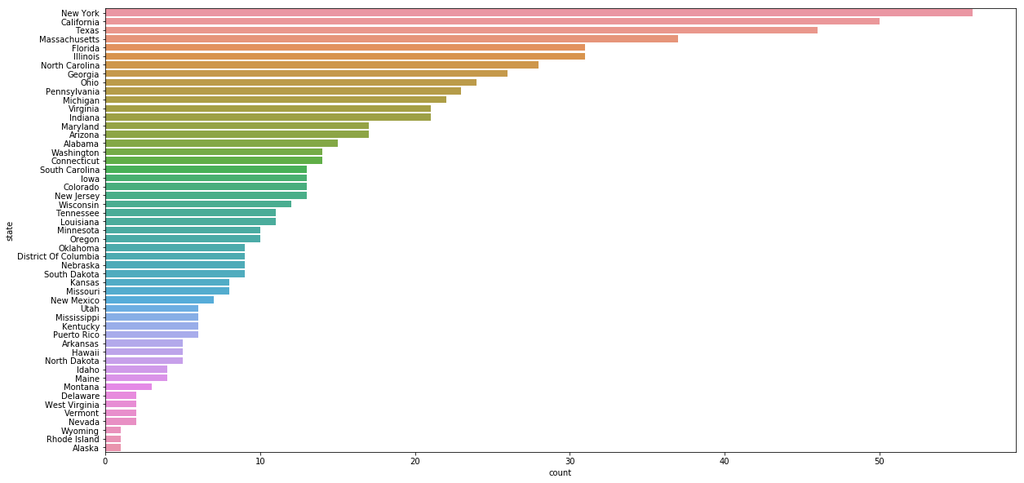

```python
plt.figure(figsize=(20,10))
order = df['state'].value_counts().index
ax = sns.countplot(y="state", order=order, data=df)
```

# Typifying Research Topics

The edges are a bit more difficult. In addition to getting a boolean "link" between two nodes, we'd also like to evalulate the strength of the connection. In this analysis, I'm interested to see what research topics are the most popular across all of the REU programs.

## KMeans Clustering

Let's do a simple K-Means clustering on the research topics to guess on the number generalized research topics. We'll cluster on the TF-IDF counts.

```python
vectorizer = TfidfVectorizer()
vectors = vectorizer.fit_transform(df.research_topics_keywords.values)
vectors
```

```
<719x1593 sparse matrix of type '<class 'numpy.float64'>'
	with 6984 stored elements in Compressed Sparse Row format>
```

```python
def get_inertias(max_k=50):
    inertias = []
    for k in range(1, max_k):
        clusterer = KMeans(n_clusters=k)
        clusterer.fit(vectors)
        inertias.append(clusterer.inertia_)
    return inertias
```

```python
inertias = get_inertias()
```

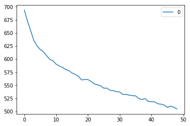

```python
pd.DataFrame(inertias).plot()
```

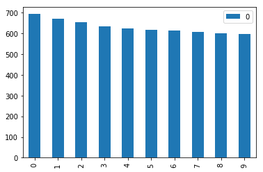

```python
pd.DataFrame(inertias[:10]).plot.bar()
```

Hmm, not super conclusive. We could also look at LDA.

# Latent Dirichlet Allocation

```python
# From: http://scikit-learn.org/stable/auto_examples/applications/plot_topics_extraction_with_nmf_lda.html#sphx-glr-auto-examples-applications-plot-topics-extraction-with-nmf-lda-py

tf = vectors
n_samples = 2000
n_features = 1000
n_components = 10
n_top_words = 20


def print_top_words(model, feature_names, n_top_words):
    for topic_idx, topic in enumerate(model.components_):
        message = "Topic #%d: " % topic_idx
        message += " ".join([feature_names[i]
                             for i in topic.argsort()[:-n_top_words - 1:-1]])
        print(message)
    print()

lda = LatentDirichletAllocation(n_components=n_components, max_iter=5,
                                learning_method='online',
                                learning_offset=50.,
                                random_state=0)
t0 = time()
lda.fit(tf)
print("done in %0.3fs." % (time() - t0))

print("\nTopics in LDA model:")
tf_feature_names = vectorizer.get_feature_names()
print_top_words(lda, tf_feature_names, n_top_words)
```

```
done in 0.436s.

Topics in LDA model:
Topic #0: reu for collaboration industry personalized structural smart site technology urm two year students college asu academia colonization preparation bioarchaeology innovative
Topic #1: bioplastics biocomposites seismology frontiers research of public veterans scientific trauma and social cancer workforce rico heart biotechnology games attack multidrug
Topic #2: chemistry theory organic security materials and physical inorganic analytical combinatorics computing mobile number biochemistry computational graph biological of energy privacy
Topic #3: physics and materials engineering astronomy science astrophysics energy nuclear matter condensed chemistry optics biophysics electrical nanotechnology particle instrumentation high chemical
Topic #4: rehabilitation engineering radiation systems servo precision sources moni controls interferometry electronics optical measurements complex gravitational including astrophysical environmental laser mechanical
Topic #5: mathematics statistics and mathematical applied robotics psychology discrete biology learning theoretical education math for neuroscience probability biomathematics combinatorics fields robots
Topic #6: bioimaging disparities and bioproduct synthesis forest sustainable production of their assemblies fuel application characterization in reu composites nanoparticles catalyst contamination
Topic #7: biology biosciences ecology science environmental biochemistry engineering chemistry marine genetics evolution molecular neuroscience cell bioinformatics geology microbiology genomics computational oceanography
Topic #8: data biomedical and learning engineering of machine systems computing computer health devices analytics processing modeling human big analysis vision interaction
Topic #9: polymer research energy power cancer grid solar and language smart storage communication electrification materials composites transportation renewable wireless vehicle systems
```

Not sure I feel compelled to use any of these.

Lets just use the convention of comma separation to our advantage, and just take the first two comma separated values that seem like small words.

```python
def get_two_first_simple_words(string, length=20):
    split = string.lower().split(',')
    # Must be comma separated
    if len(split) >= 2:
        one, two = split[0:2]
        if len(one) < length and len(two) < length:
            return one, two

    return (None, None)

def get_primary(string):
    one, two = get_two_first_simple_words(string)
    return one

def get_secondary(string):
    one, two = get_two_first_simple_words(string)
    return two
```

```python
df.research_topics_keywords.map(get_two_first_simple_words)[:10]
```

```
0                           (None, None)
1                (biology,  biosciences)
2                           (None, None)
3    (earth science,  planetary science)
4              (evolution,  systematics)
5                           (None, None)
6           (archaeology,  preservation)
7             (astronomy,  astrophysics)
8                           (None, None)
9                           (None, None)
Name: research_topics_keywords, dtype: object
```

```python
df['primary'] = df.research_topics_keywords.map(get_primary)
df['secondary'] = df.research_topics_keywords.map(get_secondary)
```

```python
subset = df[~df.primary.isna()]
len(subset)
```

```
325
```

# Making Network Graphs

We'll look at a few ways of making graphs.

```python
# Simply using holoview directly
source, target = subset.institution.values, subset.primary.values
padding = dict(x=(-1.2, 1.2), y=(-1.2, 1.2))
graph = hv.Graph(((source, target),)).redim.range(**padding)
```

```python
graph
```

[output not shown]

```python
# Using networkx
G = nx.Graph()
```

```python
G.add_nodes_from(subset.institution)
G.add_nodes_from(subset.primary)
G.add_edges_from(subset[['institution', 'primary']].values)

# We can still use holoview
hv.Graph.from_networkx(G, nx.spring_layout)
```

[output not shown]

```python
# Using different layouts
graph = hv.Graph.from_networkx(G, nx.kamada_kawai_layout)
graph
```

[output not shown]

# Exporting to use with Gephi

Networkx will also let you export your graph pretty easily to use it with https://gephi.org/. The visualization options are way more flexible with that software!

```python
nx.write_gexf(G, 'nsf_reu.gexf')
```